# Social Media Assigment

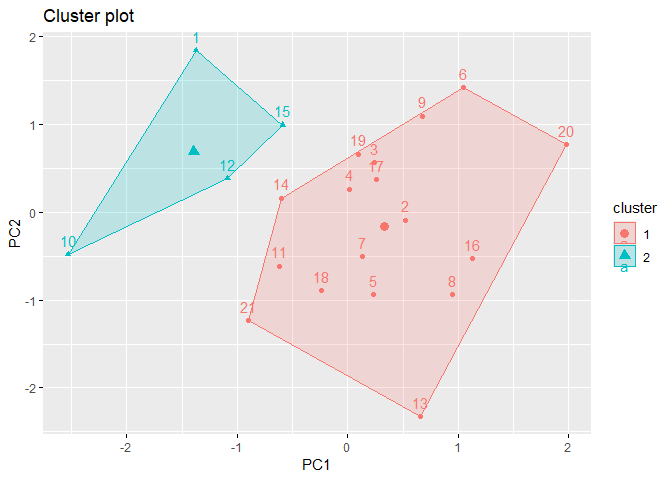

```r
# Visualize cluster and membership using first two Principal Components
fviz_cluster(list(data = pc$x[, 1:2], cluster = kmeans_model$cluster))
```

Using the first two principal components, the clusters and their memberships are seen in this graphic. After removing these elements from the data, k-means clustering is used to place each data point in a cluster. Lastly, it produces a graphic depicting how the data points are arranged in the first two primary components according to their similarities.

What connection exists between the k-means algorithm’s clustering findings and Principal Component Analysis (PCA)’s identification of the data’s underlying structure?

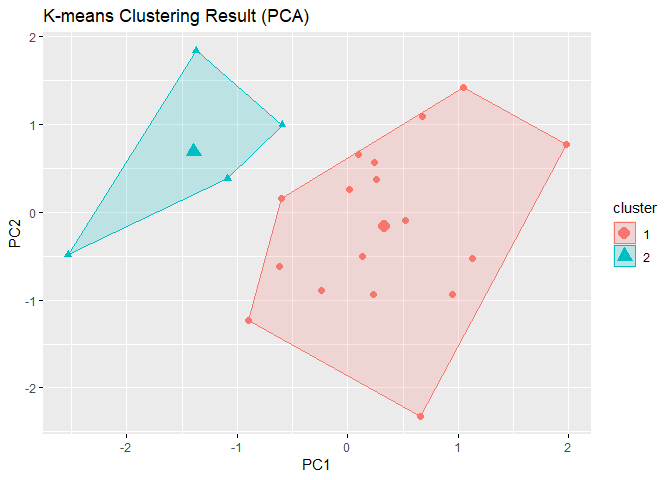

```r
# Visualize cluster and membership using first two Principal Components for k-means
pca_result <- prcomp(data, scale = TRUE)
fviz_cluster(kmeans_model, data = pca_result$x[, 1:2], geom = "point",
             pointsize = 2, fill = "white", main = "K-means Clustering Result (PCA)")
```

How can one determine the ideal number of clusters for a particular dataset based on the link between the number of clusters (k) and the average silhouette width in k-means clustering?

```
##   cluster size ave.sil.width
## 1       1   17          0.26
## 2       2    4         -0.06
```

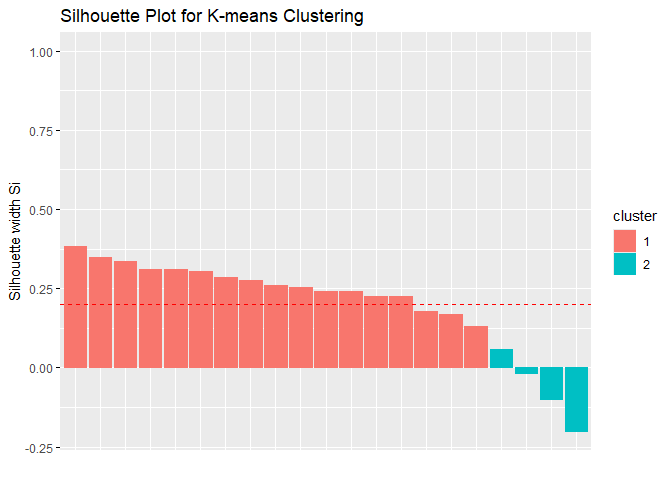

```r
# Calculate silhouette information for k-means clustering
sil <- silhouette(kmeans_model$cluster, dist(data))

# Visualize the silhouette plot for k-means clustering
fviz_silhouette(sil, main = "Silhouette Plot for K-means Clustering")
```

This graphic computes and displays the k-means clustering silhouette data. By comparing an object’s similarity to its own cluster to that of other clusters, silhouette analysis assesses the quality of clustering. Better cluster separation is indicated by a wider silhouette, but negative values imply that points may have been allocated to the incorrect groups. This figure aids in figuring out how many clusters to use for k-means clustering and evaluating the effectiveness of clustering overall.

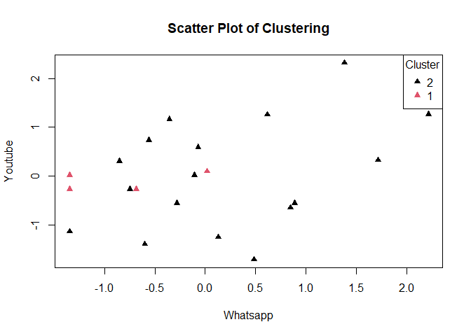

```r
# Create a data frame with cluster membership
data_clustered <- data.frame(data, Cluster = kmeans_model$cluster)  # Ensure conversion to data frame

# Scatter plot of data points colored by cluster membership
plot(data_clustered$Whatsapp.Wechat, data_clustered$youtube,
     col = data_clustered$Cluster, pch = 17,
     xlab = "Whatsapp", ylab = "Youtube",
     main = "Scatter Plot of Clustering")
legend("topright", legend = unique(data_clustered$Cluster),
       col = 1:max(data_clustered$Cluster), pch = 17, title = "Cluster")
```

With each group represented by a different hue on the plot, this visualization of the data helps us see how the data points group together based on Whatsapp and Youtube.

### Factor Analysis

[output not shown]

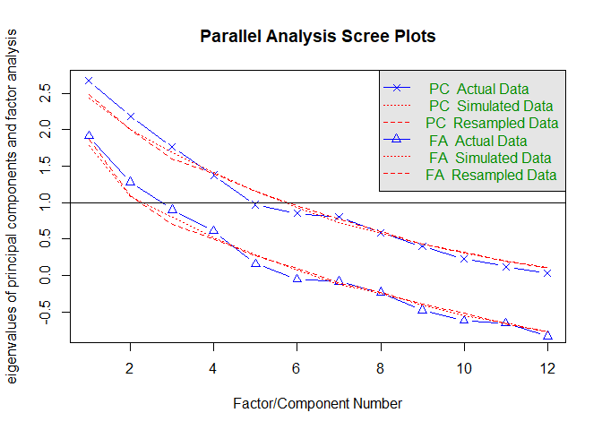

```
## Parallel analysis suggests that the number of factors =  0  and the number of components =  0
```

```r
fa.parallel(social_media_numeric)
```

Parallel analysis suggests that the number of factors = 0 and the number of components = 0

```r
fit.pc <- principal(social_media_numeric, nfactors=2, rotate="varimax")
fit.pc
```

```
## Principal Components Analysis
## Call: principal(r = social_media_numeric, nfactors = 2, rotate = "varimax")
## Standardized loadings (pattern matrix) based upon correlation matrix
##                                 RC1   RC2   h2   u2 com
## Instagram                      0.56  0.39 0.46 0.54 1.8
## LinkedIn                       0.73 -0.16 0.55 0.45 1.1
## SnapChat                       0.11  0.54 0.31 0.69 1.1
## Twitter                       -0.16 -0.54 0.32 0.68 1.2
## Whatsapp/Wechat                0.65  0.21 0.47 0.53 1.2
## youtube                        0.71 -0.18 0.53 0.47 1.1
## OTT                            0.41 -0.37 0.30 0.70 2.0
## Reddit                         0.03 -0.39 0.15 0.85 1.0
## Trouble_falling_asleep         0.10  0.69 0.48 0.52 1.0
## Mood Productivity              0.53  0.27 0.35 0.65 1.5
## Tired waking up in morning    -0.30  0.73 0.62 0.38 1.3
## How you felt the entire week?  0.39  0.41 0.31 0.69 2.0
##
##                        RC1  RC2
## SS loadings           2.49 2.37
## Proportion Var        0.21 0.20
## Cumulative Var        0.21 0.40
## Proportion Explained  0.51 0.49
## Cumulative Proportion 0.51 1.00
##
## Mean item complexity =  1.4
## Test of the hypothesis that 2 components are sufficient.
##
## The root mean square of the residuals (RMSR) is  0.16
##  with the empirical chi square  72.39  with prob <  0.0033
##
## Fit based upon off diagonal values = 0.56
```

A strong correlation between the variable and the factor is shown by high absolute values, which are in proximity to 1. The amount by which the factors account for the variance of the variables is explained by \#h2. The amount of variance not explained by the factors is indicated by \#u2. Analysis of Principal Components Call: principal(nfactors = 2, rotate = “varimax,” r = social_media_numeric) Pattern matrix standardizations based on correlation matrix.

```r
round(fit.pc$values, 3)
```

```
##  [1] 2.676 2.183 1.764 1.378 0.971 0.851 0.805 0.587 0.401 0.229 0.120 0.035
```

```r
fit.pc$loadings
```

```
##
## Loadings:
##                               RC1    RC2
## Instagram                      0.556  0.389
## LinkedIn                       0.725 -0.161
## SnapChat                       0.109  0.541
## Twitter                       -0.164 -0.539
## Whatsapp/Wechat                0.650  0.208
## youtube                        0.707 -0.184
## OTT                            0.407 -0.373
## Reddit                               -0.388
## Trouble_falling_asleep         0.104  0.688
## Mood Productivity              0.527  0.265
## Tired waking up in morning    -0.303  0.728
## How you felt the entire week?  0.386  0.406
##
##                  RC1   RC2
## SS loadings    2.494 2.366
## Proportion Var 0.208 0.197
## Cumulative Var 0.208 0.405
```

```r
fit.pc$communality
```

```
##                     Instagram                      LinkedIn
##                     0.4609883                     0.5521648
##                      SnapChat                       Twitter
##                     0.3051221                     0.3177808
##               Whatsapp/Wechat                       youtube
##                     0.4664790                     0.5332625
##                           OTT                        Reddit
##                     0.3043824                     0.1510324
##        Trouble_falling_asleep             Mood Productivity
##                     0.4843960                     0.3481044
##    Tired waking up in morning How you felt the entire week?
##                     0.6217976                     0.3138161
```

```r
# Rotated factor scores, Notice the columns ordering: RC1, RC2
fit.pc
```

```
## Principal Components Analysis
## Call: principal(r = social_media_numeric, nfactors = 2, rotate = "varimax")
## Standardized loadings (pattern matrix) based upon correlation matrix
##                                 RC1   RC2   h2   u2 com
## Instagram                      0.56  0.39 0.46 0.54 1.8
## LinkedIn                       0.73 -0.16 0.55 0.45 1.1
## SnapChat                       0.11  0.54 0.31 0.69 1.1
## Twitter                       -0.16 -0.54 0.32 0.68 1.2
## Whatsapp/Wechat                0.65  0.21 0.47 0.53 1.2
## youtube                        0.71 -0.18 0.53 0.47 1.1
## OTT                            0.41 -0.37 0.30 0.70 2.0
## Reddit                         0.03 -0.39 0.15 0.85 1.0
## Trouble_falling_asleep         0.10  0.69 0.48 0.52 1.0
## Mood Productivity              0.53  0.27 0.35 0.65 1.5
## Tired waking up in morning    -0.30  0.73 0.62 0.38 1.3
## How you felt the entire week?  0.39  0.41 0.31 0.69 2.0
##
##                        RC1  RC2
## SS loadings           2.49 2.37
## Proportion Var        0.21 0.20
## Cumulative Var        0.21 0.40
## Proportion Explained  0.51 0.49
## Cumulative Proportion 0.51 1.00
##
## Mean item complexity =  1.4
## Test of the hypothesis that 2 components are sufficient.
##
## The root mean square of the residuals (RMSR) is  0.16
##  with the empirical chi square  72.39  with prob <  0.0033
##
## Fit based upon off diagonal values = 0.56
```

```r
fit.pc$scores
```

```
##               RC1        RC2
##  [1,]  0.03152026 -2.3010655
##  [2,]  0.36294009  0.3883794
##  [3,]  0.53677836 -0.3028726
##  [4,]  0.17219105 -0.1995664
##  [5,] -0.38726442  0.8816096
##  [6,]  1.69693355 -0.4887786
##  [7,] -0.20079571  0.4843012
##  [8,]  0.18221986  1.3207815
##  [9,]  1.20640012 -0.4572010
## [10,] -2.30030270 -1.1572244
## [11,] -0.86395523  0.1114352
## [12,] -0.62706223 -0.9675326
## [13,] -0.89610952  2.2463127
## [14,] -0.38157128 -0.4965518
## [15,]  0.13564058 -1.1499638
## [16,]  0.57178788  1.1075723
## [17,]  0.43480529 -0.1367564
## [18,] -0.72969671  0.5643957
## [19,]  0.48277403 -0.4673222
## [20,]  2.03958577  0.5916007
## [21,] -1.46681906  0.4284470
```

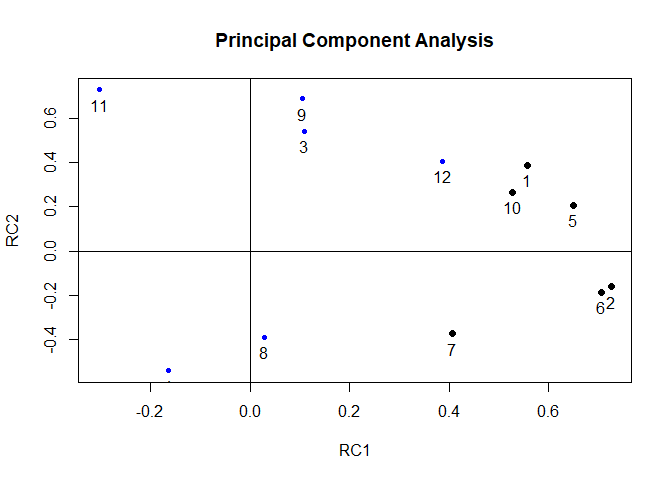

```r
fa.plot(fit.pc)
```

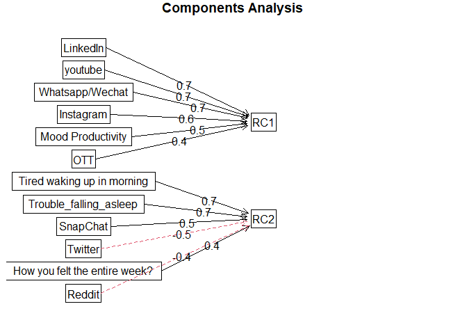

```r
fa.diagram(fit.pc) # Visualize the relationship
```

```r
vss(social_media_numeric)
```

[output not shown]

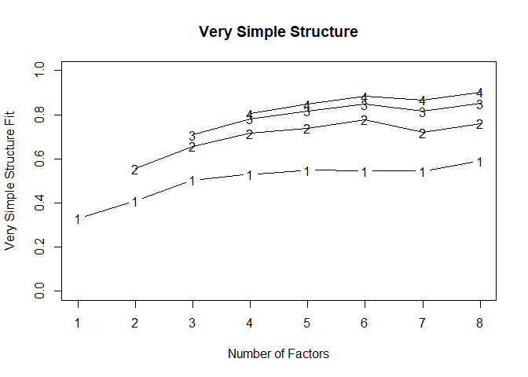

```
##
## Very Simple Structure
## Call: vss(x = social_media_numeric)
## Although the VSS complexity 1 shows  8  factors, it is probably more reasonable to think about  5  factors
## VSS complexity 2 achieves a maximimum of 0.78  with  6  factors
##
## The Velicer MAP achieves a minimum of 0.07  with  1  factors
## BIC achieves a minimum of  -88.66  with  1  factors
## Sample Size adjusted BIC achieves a minimum of  7.84  with  7  factors
##
## Statistics by number of factors
##   vss1 vss2   map dof chisq  prob sqresid  fit RMSEA   BIC SABIC complex eChisq
## 1 0.33 0.00 0.067  54  75.7 0.027   13.27 0.33 0.130 -88.7  78.0     1.0  97.32
## 2 0.41 0.56 0.075  43  60.4 0.041    8.80 0.56 0.130 -70.5  62.2     1.4  55.37
## 3 0.50 0.66 0.086  33  43.8 0.098    5.77 0.71 0.115 -56.6  45.2     1.6  27.84
## 4 0.53 0.72 0.100  24  28.8 0.227    3.85 0.81 0.085 -44.2  29.8     1.6  11.34
## 5 0.55 0.74 0.125  16  20.4 0.201    2.85 0.86 0.104 -28.3  21.1     1.8   5.58
## 6 0.55 0.78 0.175   9  15.6 0.075    2.02 0.90 0.181 -11.8  16.0     1.7   3.32
## 7 0.54 0.72 0.209   3   7.7 0.052    1.74 0.91 0.269  -1.4   7.8     2.0   1.21
## 8 0.59 0.76 0.284  -2   4.9    NA    0.87 0.96    NA    NA    NA     1.9   0.41
##    SRMR eCRMS  eBIC
## 1 0.187 0.207 -67.1
## 2 0.141 0.175 -75.5
## 3 0.100 0.142 -72.6
## 4 0.064 0.106 -61.7
## 5 0.045 0.091 -43.1
## 6 0.035 0.094 -24.1
## 7 0.021 0.098  -7.9
## 8 0.012    NA    NA
```

Statistics by number of factors

```r
# Computing Correlation Matrix
corrm.social <- cor(social_media_numeric)
corrm.social
```

```
##                                 Instagram     LinkedIn    SnapChat     Twitter
## Instagram                      1.00000000  0.097056399  0.28968877 -0.19305653
## LinkedIn                       0.09705640  1.000000000  0.02552545 -0.13006846
## SnapChat                       0.28968877  0.025525452  1.00000000 -0.17995686
## Twitter                       -0.19305653 -0.130068464 -0.17995686  1.00000000
## Whatsapp/Wechat                0.37769615  0.228835623  0.08099980 -0.49583293
## youtube                        0.33000187  0.452197669 -0.16006877 -0.18817769
## OTT                            0.26738122  0.185492527  0.13158590  0.55707401
## Reddit                        -0.07461553 -0.006992884 -0.08116237  0.16490296
## Trouble_falling_asleep         0.50535856 -0.124658176  0.47446668 -0.07841779
## Mood Productivity              0.37498880  0.335447863  0.13051708  0.10299576
## Tired waking up in morning     0.06883078 -0.327465831  0.18918923 -0.27223450
## How you felt the entire week? -0.06488863  0.415506031  0.07962803 -0.14557124
##                               Whatsapp/Wechat      youtube           OTT
## Instagram                          0.37769615  0.330001869  0.2673812155
## LinkedIn                           0.22883562  0.452197669  0.1854925268
## SnapChat                           0.08099980 -0.160068767  0.1315859038
## Twitter                           -0.49583293 -0.188177691  0.5570740080
## Whatsapp/Wechat                    1.00000000  0.371685163  0.1336203696
## youtube                            0.37168516  1.000000000  0.1605652338
## OTT                                0.13362037  0.160565234  1.0000000000
## Reddit                            -0.13444966  0.026399913  0.2327910994
## Trouble_falling_asleep            -0.06304856  0.038656332 -0.0004560485
## Mood Productivity                  0.30887192 -0.003621212  0.1532080319
## Tired waking up in morning        -0.04248925 -0.355519106 -0.2213138016
## How you felt the entire week?      0.18772672  0.178774630 -0.1088494499
##                                     Reddit Trouble_falling_asleep
## Instagram                     -0.074615529           0.5053585585
## LinkedIn                      -0.006992884          -0.1246581760
## SnapChat                      -0.081162369           0.4744666806
## Twitter                        0.164902964          -0.0784177942
## Whatsapp/Wechat               -0.134449660          -0.0630485641
## youtube                        0.026399913           0.0386563318
## OTT                            0.232791099          -0.0004560485
## Reddit                         1.000000000          -0.1403872651
## Trouble_falling_asleep        -0.140387265           1.0000000000
## Mood Productivity              0.075429291           0.1581138830
## Tired waking up in morning    -0.140387265           0.3571428571
## How you felt the entire week? -0.155986035           0.2773500981
##                               Mood Productivity Tired waking up in morning
```

[output cut: 10 more lines]

```
## Tired waking up in morning          0.158113883                 1.00000000
## How you felt the entire week?       0.438529010                 0.27735010
##                               How you felt the entire week?
## Instagram                                       -0.06488863
## LinkedIn                                         0.41550603
## SnapChat                                         0.07962803
## Twitter                                         -0.14557124
## Whatsapp/Wechat                                  0.18772672
## youtube                                          0.17877463
## OTT                                             -0.10884945
## Reddit                                          -0.15598604
## Trouble_falling_asleep                           0.27735010
## Mood Productivity                                0.43852901
## Tired waking up in morning                       0.27735010
## How you felt the entire week?                    1.00000000
```

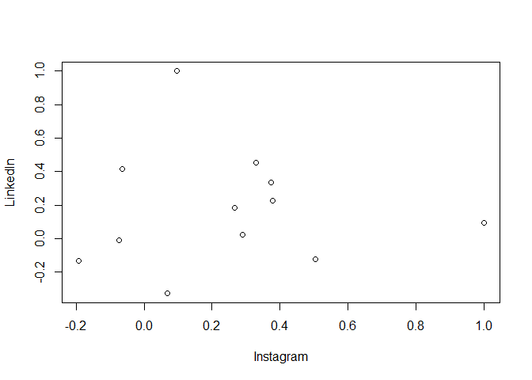

```r
plot(corrm.social)
```

```r
social_pca <- prcomp(social_media_numeric, scale=TRUE)
summary(social_pca)
```

```
## Importance of components:
##                          PC1    PC2    PC3    PC4     PC5     PC6    PC7
## Standard deviation     1.636 1.4776 1.3280 1.1739 0.98548 0.92264 0.8974
## Proportion of Variance 0.223 0.1819 0.1470 0.1148 0.08093 0.07094 0.0671
## Cumulative Proportion  0.223 0.4049 0.5519 0.6667 0.74767 0.81861 0.8857
##                            PC8     PC9    PC10    PC11   PC12
## Standard deviation     0.76608 0.63298 0.47850 0.34662 0.1866
## Proportion of Variance 0.04891 0.03339 0.01908 0.01001 0.0029
## Cumulative Proportion  0.93462 0.96801 0.98709 0.99710 1.0000
```

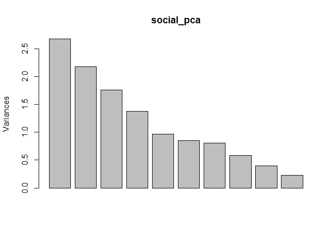

```r
plot(social_pca)
```

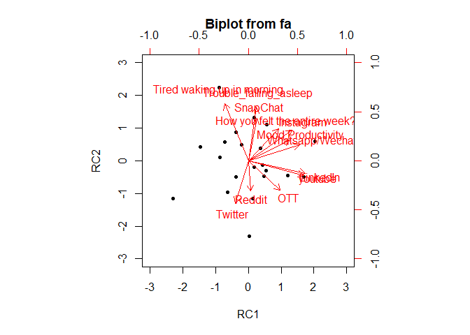

```r
biplot(fit.pc)
```

All things considered, these methods work well in tandem and can be applied to acquire a thorough comprehension of the information, reveal hidden patterns and structures, and produce insightful conclusions for further research and decision-making.

#### Multiple Regression Analysis

```r
social_media <- read_excel("social_media_cleaned.xlsx")
social_media_numeric <- select_if(social_media, is.numeric)
```

#### Model Development

```r
model <- lm(social_media_numeric$Trouble_falling_asleep  ~ social_media_numeric$Instagram + social_media_numeric$LinkedIn + social_media_numeric$SnapChat + social_media_numeric$Twitter + social_media_numeric$`Whatsapp/Wechat` + social_media_numeric$youtube + social_media_numeric$OTT + social_media_numeric$Reddit,
            data = social_media_numeric
)
summary(model)
```

```
##
## Call:
## lm(formula = social_media_numeric$Trouble_falling_asleep ~ social_media_numeric$Instagram +
##     social_media_numeric$LinkedIn + social_media_numeric$SnapChat +
##     social_media_numeric$Twitter + social_media_numeric$`Whatsapp/Wechat` +
##     social_media_numeric$youtube + social_media_numeric$OTT +
##     social_media_numeric$Reddit, data = social_media_numeric)
##
## Residuals:
##      Min       1Q   Median       3Q      Max
## -0.47240 -0.26171 -0.04857  0.14431  0.71319
##
## Coefficients:
##                                        Estimate Std. Error t value Pr(>|t|)
## (Intercept)                             0.02935    0.36730   0.080    0.938
## social_media_numeric$Instagram          0.07008    0.03479   2.014    0.067 .
## social_media_numeric$LinkedIn          -0.02846    0.04682  -0.608    0.555
## social_media_numeric$SnapChat           0.05725    0.03387   1.690    0.117
## social_media_numeric$Twitter            0.03816    0.14738   0.259    0.800
## social_media_numeric$`Whatsapp/Wechat` -0.02922    0.03663  -0.798    0.441
## social_media_numeric$youtube            0.04025    0.07350   0.548    0.594
## social_media_numeric$OTT               -0.02642    0.05020  -0.526    0.608
## social_media_numeric$Reddit            -0.02379    0.06667  -0.357    0.727
## ---
## Signif. codes:  0 '***' 0.001 '**' 0.01 '*' 0.05 '.' 0.1 ' ' 1
##
## Residual standard error: 0.4432 on 12 degrees of freedom
## Multiple R-squared:  0.495,  Adjusted R-squared:  0.1583
## F-statistic:  1.47 on 8 and 12 DF,  p-value: 0.2639
```

We examine the relevant t- and p-values for each coefficient to determine its statistical significance. A predictor variable may be statistically important in explaining the variability in sleep problems if it has a low p-value, which is often less than 0.05. Put more simply, it indicates that there is a good chance that the variable actually affects sleep problems.

#### Model Acceptance

```r
coefficients(model)
```

```
##                            (Intercept)         social_media_numeric$Instagram
##                             0.02935003                             0.07007642
##          social_media_numeric$LinkedIn          social_media_numeric$SnapChat
##                            -0.02846038                             0.05724962
##           social_media_numeric$Twitter social_media_numeric$`Whatsapp/Wechat`
##                             0.03816260                            -0.02922242
##           social_media_numeric$youtube               social_media_numeric$OTT
##                             0.04025224                            -0.02641988
##            social_media_numeric$Reddit
##                            -0.02379311
```

```r
confint(model,level=0.95)
```

```
##                                               2.5 %     97.5 %
## (Intercept)                            -0.770927154 0.82962722
## social_media_numeric$Instagram         -0.005728035 0.14588087
## social_media_numeric$LinkedIn          -0.130465001 0.07354424
## social_media_numeric$SnapChat          -0.016539324 0.13103857
## social_media_numeric$Twitter           -0.282947122 0.35927233
## social_media_numeric$`Whatsapp/Wechat` -0.109032432 0.05058759
## social_media_numeric$youtube           -0.119892516 0.20039700
## social_media_numeric$OTT               -0.135799283 0.08295953
## social_media_numeric$Reddit            -0.169058947 0.12147272
```

```r
fitted(model)
```

```
##           1           2           3           4           5           6
##  0.03767577  0.68297470 -0.14111191  0.20249080  0.85568960 -0.12780750
##           7           8           9          10          11          12
##  0.23700749  0.28681294  0.47239558  0.13256374  0.41692826  0.27284963
##          13          14          15          16          17          18
##  1.09915634  0.43420708  0.04857065  0.41826973  0.41113911  0.32212351
##          19          20          21
##  0.26171236  0.88332910 -0.20697699
```

#### Residual Analysis

```r
residuals(model)
```

```
##           1           2           3           4           5           6
## -0.03767577  0.31702530  0.14111191 -0.20249080  0.14431040  0.12780750
##           7           8           9          10          11          12
## -0.23700749  0.71318706 -0.47239558 -0.13256374  0.58307174 -0.27284963
##          13          14          15          16          17          18
## -0.09915634 -0.43420708 -0.04857065  0.58173027 -0.41113911 -0.32212351
##          19          20          21
## -0.26171236  0.11667090  0.20697699
```

```r
anova(model)
```

```
## Analysis of Variance Table
##
## Response: social_media_numeric$Trouble_falling_asleep
##                                        Df  Sum Sq Mean Sq F value  Pr(>F)
## social_media_numeric$Instagram          1 1.19181 1.19181  6.0682 0.02985 *
## social_media_numeric$LinkedIn           1 0.14215 0.14215  0.7238 0.41156
## social_media_numeric$SnapChat           1 0.54677 0.54677  2.7839 0.12108
## social_media_numeric$Twitter            1 0.00972 0.00972  0.0495 0.82772
## social_media_numeric$`Whatsapp/Wechat`  1 0.26490 0.26490  1.3488 0.26808
## social_media_numeric$youtube            1 0.04226 0.04226  0.2152 0.65103
## social_media_numeric$OTT                1 0.08720 0.08720  0.4440 0.51780
## social_media_numeric$Reddit             1 0.02501 0.02501  0.1274 0.72739
## Residuals                              12 2.35684 0.19640
## ---
## Signif. codes:  0 '***' 0.001 '**' 0.01 '*' 0.05 '.' 0.1 ' ' 1
```

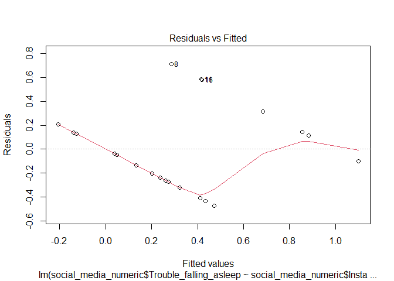

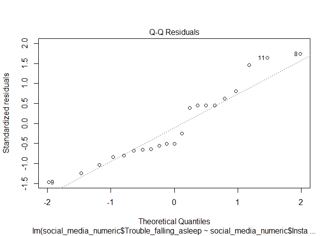

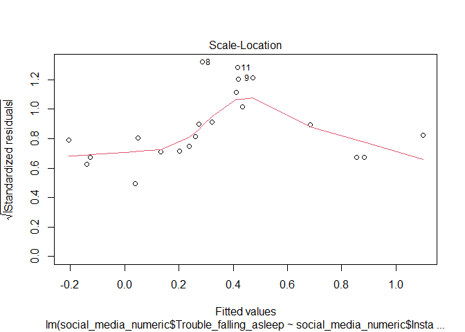

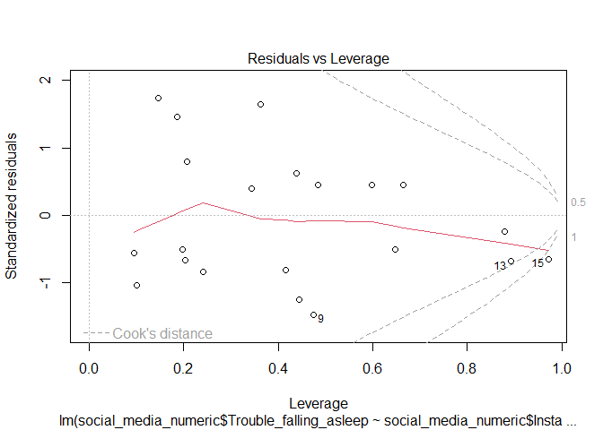

```r
plot(model)
```

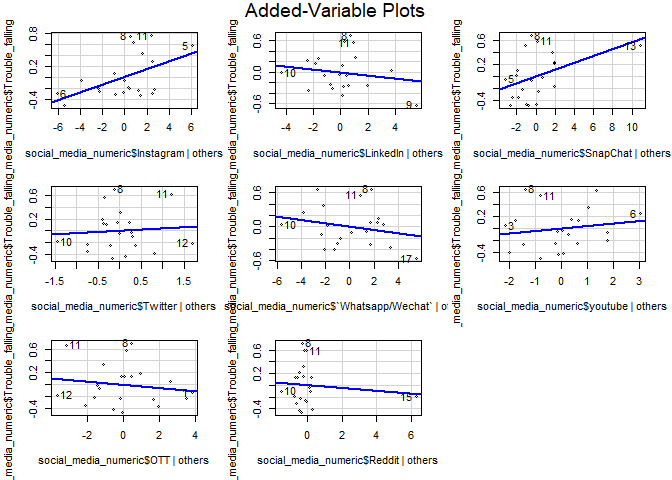

```r
avPlots(model)
```

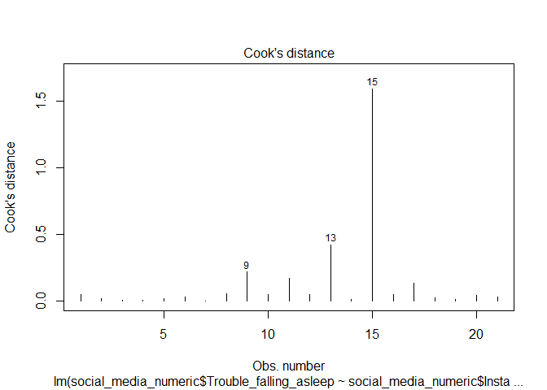

```r
cutoff <- 17/((nrow(social_media)-length(model$coefficients)-2))
plot(model, which=4, cook.levels=cutoff)
```

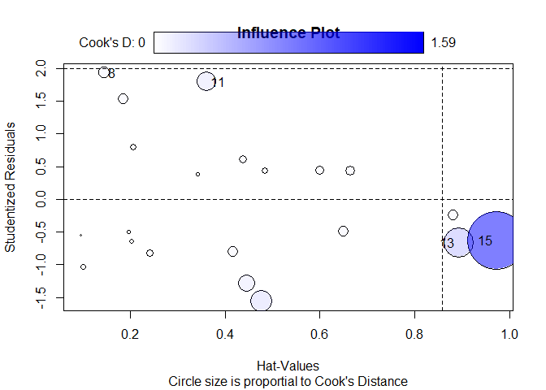

```
##       StudRes       Hat      CookD
## 8   1.9283209 0.1457607 0.05747738
## 11  1.7930758 0.3622253 0.17127619
## 13 -0.6643396 0.8918546 0.42415845
## 15 -0.6322389 0.9714537 1.59103287
```

```r
influencePlot(model, id.method="identify", main="Influence Plot", sub="Circle size is proportial to Cook's Distance" )
```

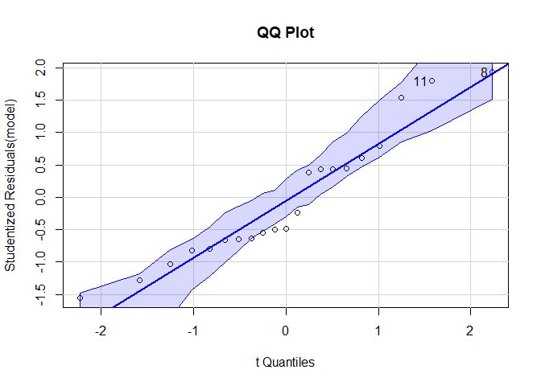

```
## [1]  8 11
```

```r
qqPlot(model, main="QQ Plot")
```

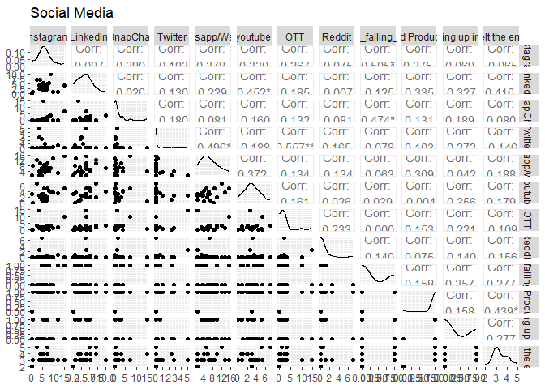

```r
ggpairs(data=social_media_numeric, title="Social Media")
```

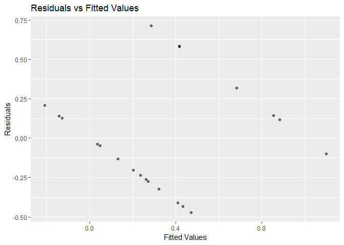

```r
ggplot(social_media_numeric, aes(x = fitted(model), y = residuals(model))) +
  geom_point(alpha = 0.5) +
  labs(title = "Residuals vs Fitted Values", x = "Fitted Values", y = "Residuals")
```

One method for assessing a regression model’s assumptions and suitability is the residual vs. fitted graphic. It is useful in determining whether the model accurately depicts the underlying relationships in the data or whether there are problems that require attention. Plotting a pattern of points around zero indicates that the model is inappropriate.

Based on the supplied predictors, the predict() method will produce anticipated values for the dependent variable (Trouble_falling_asleep).

```r
new_data_pd <- data.frame(
  character = "masinl",
  Instagram = 3.50,
  LinkedIn = 4.00,
  SnapChat = 1.00,
  Twitter = 5.00,
  `Whatsapp/Wechat` = 1.00,
  youtube = 2.50,
  OTT = 14.50,
  Reddit = 2.50,
  Trouble_falling_asleep = 0,
  Mood = 1,
  Productivity = 0,
  Tired_waking_up_in_morning = 3,
  `How you felt the entire week?` = 3
)

predicted_pd <- predict(model, newdata = new_data_pd)
predicted_pd
```

```
##           1           2           3           4           5           6
##  0.03767577  0.68297470 -0.14111191  0.20249080  0.85568960 -0.12780750
##           7           8           9          10          11          12
##  0.23700749  0.28681294  0.47239558  0.13256374  0.41692826  0.27284963
##          13          14          15          16          17          18
##  1.09915634  0.43420708  0.04857065  0.41826973  0.41113911  0.32212351
##          19          20          21
##  0.26171236  0.88332910 -0.20697699
```

```r
summary(predicted_pd)
```

```
##    Min. 1st Qu.  Median    Mean 3rd Qu.    Max.
## -0.2070  0.1326  0.2868  0.3333  0.4342  1.0992
```

#### Model Accuracy

```r
rsquared <- summary(model)$r.squared
cat("R-squared:", rsquared, "\n")
```

```
## R-squared: 0.494963
```

```r
adjusted_rsquared <- summary(model)$adj.r.squared
cat("Adjusted R-squared:", adjusted_rsquared, "\n")
```

```
## Adjusted R-squared: 0.1582717
```

```r
predictions <- predict(model)
rmse <- sqrt(mean((social_media$Instagram - predictions)^2))
cat("RMSE:", rmse, "\n")
```

```
## RMSE: 6.442152
```

### Logistic Regression Analysis

To perform logistic regression analysis, we will use the glm() function.

- Load all necessary packages
- Load Data. we Used read_excel() function to read data from excel
- Now we will use glm() function to fit a logistic regression model to the data.
- Use the logistic regression model’s summary() function to examine the coefficients, standard errors, z-values, and p-values.
- To obtain the residual analysis, utilize the plot() function. To verify that the residuals are homoscedastic and normal, plot diagnostic plots such as residuals vs. fitted values, scale-location plot, and QQ plot of residuals.

#### Model Development

```r
social_media <- read_excel("social_media_cleaned.xlsx")
social_media_numeric <- select_if(social_media, is.numeric)
```

Using Instagram, WhatsApp, OTT, and YouTube usage as variables, a logistic regression model is developed to calculate the likelihood of experiencing sleep problems.

```r
Instagram_lab <- cut(social_media$Instagram, breaks = c(-Inf, 6, Inf), labels = c("Low Usage", "High Usage"))
WhatsApp_lab <- cut(social_media$`Whatsapp/Wechat`, breaks = c(-Inf, 6, Inf), labels = c("Low Usage", "High Usage"))
OTT_lab <- cut(social_media$OTT, breaks = c(-Inf, 6, Inf), labels = c("Low Usage", "High Usage"))
YouTube_lab <- cut(social_media$youtube, breaks = c(-Inf, 6, Inf), labels = c("Low Usage", "High Usage"))

combined_lab <- interaction(WhatsApp_lab, OTT_lab, YouTube_lab)

tfs_table <- xtabs(~ Trouble_falling_asleep + combined_lab, data=social_media)
tfs_table
```

```
##                       combined_lab
## Trouble_falling_asleep Low Usage.Low Usage.Low Usage
##                      0                             5
##                      1                             5
##                       combined_lab
## Trouble_falling_asleep High Usage.Low Usage.Low Usage
##                      0                              7
##                      1                              1
##                       combined_lab
## Trouble_falling_asleep Low Usage.High Usage.Low Usage
##                      0                              1
##                      1                              0
##                       combined_lab
## Trouble_falling_asleep High Usage.High Usage.Low Usage
##                      0                               0
##                      1                               1
##                       combined_lab
## Trouble_falling_asleep Low Usage.Low Usage.High Usage
##                      0                              0
##                      1                              0
##                       combined_lab
## Trouble_falling_asleep High Usage.Low Usage.High Usage
##                      0                               1
##                      1                               0
##                       combined_lab
## Trouble_falling_asleep Low Usage.High Usage.High Usage
##                      0                               0
##                      1                               0
##                       combined_lab
## Trouble_falling_asleep High Usage.High Usage.High Usage
##                      0                                0
##                      1                                0
```

```r
logit_model <- glm(Trouble_falling_asleep ~  Instagram + `Whatsapp/Wechat` + OTT + youtube, data = social_media,
                   family = binomial)
```

The code creates a binary result variable based on a threshold by reading a dataset and performing preprocessing on it..

Defining the model formula, fitting the model to the data, and producing a summary of the model’s coefficients and statistical significance are all steps in this model development process.

#### Model Acceptance

```r
summary(logit_model)
```

```
##
## Call:
## glm(formula = Trouble_falling_asleep ~ Instagram + `Whatsapp/Wechat` +
##     OTT + youtube, family = binomial, data = social_media)
##
## Coefficients:
##                   Estimate Std. Error z value Pr(>|z|)
## (Intercept)        -3.1311     2.0675  -1.514   0.1299
## Instagram           0.9933     0.5214   1.905   0.0568 .
## `Whatsapp/Wechat`  -0.4055     0.2767  -1.465   0.1428
## OTT                -0.2050     0.3500  -0.586   0.5581
## youtube            -0.4078     0.5084  -0.802   0.4224
## ---
## Signif. codes:  0 '***' 0.001 '**' 0.01 '*' 0.05 '.' 0.1 ' ' 1
##
## (Dispersion parameter for binomial family taken to be 1)
##
##     Null deviance: 26.734  on 20  degrees of freedom
## Residual deviance: 16.122  on 16  degrees of freedom
## AIC: 26.122
##
## Number of Fisher Scoring iterations: 6
```

```r
anova(logit_model)
```

```
## Analysis of Deviance Table
##
## Model: binomial, link: logit
##
## Response: Trouble_falling_asleep
##
## Terms added sequentially (first to last)
##
##
##                   Df Deviance Resid. Df Resid. Dev
## NULL                                 20     26.734
## Instagram          1   5.9366        19     20.797
## `Whatsapp/Wechat`  1   3.3483        18     17.449
## OTT                1   0.6339        17     16.815
## youtube            1   0.6927        16     16.122
```

The coefficients show how each predictor variable is expected to affect the outcome variable’s log-odds of falling into the positive class (1).

#### Residual Analysis

```r
# Residual Analysis
residuals(logit_model)
```

```
##           1           2           3           4           5           6
## -0.18566301  0.75119378 -0.14561863 -0.73897415  0.08032908 -0.01458191
##           7           8           9          10          11          12
## -0.64722166  1.91673384 -1.49482860 -0.14181556  0.93227777 -0.37238419
##          13          14          15          16          17          18
##  1.10255495 -1.27161868 -0.34050877  1.37328298 -0.93695033 -1.16612969
##          19          20          21
## -0.28016130  0.66281236 -0.06369927
```

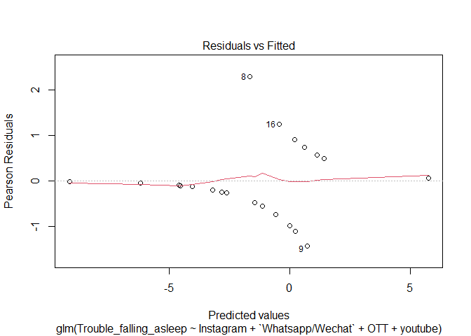

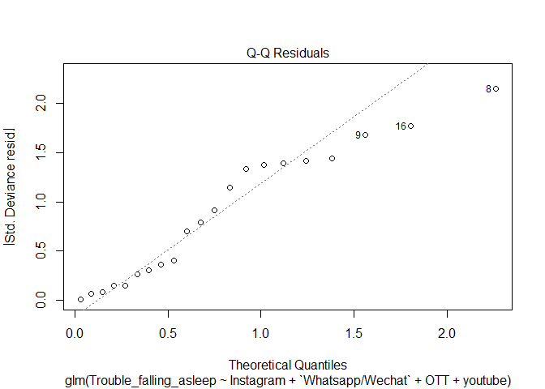

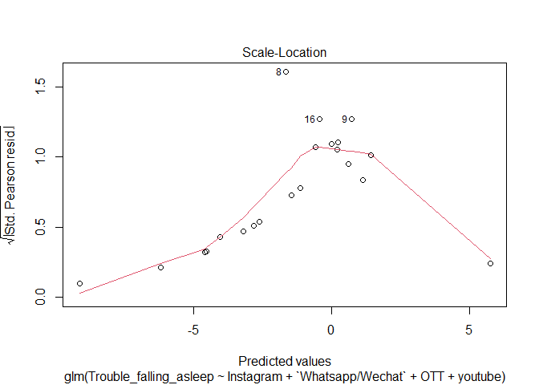

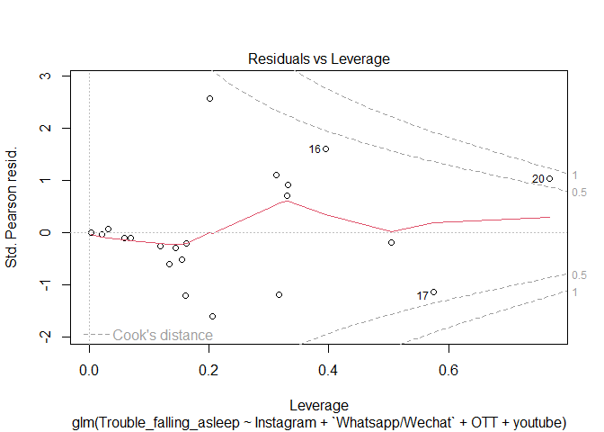

```r
plot(logit_model)
```

The function logit_model computes the residuals of the fitted logistic regression model. It yields a vector with the residuals in it.

For the logistic regression model (logit_model), the Plot() function creates diagnostic graphs. These plots include the quantile-quantile (Q-Q) plot, leverage plot, and residuals vs. fitted values.

#### Prediction

```r
predicted.social_media <- data.frame(probability.of.hd=logit_model$fitted.values,Instagram=Instagram_lab)
predicted.social_media
```

```
##    probability.of.hd  Instagram
## 1       0.0170876964  Low Usage
## 2       0.7541635351 High Usage
## 3       0.0105463853  Low Usage
## 4       0.2389387173  Low Usage
## 5       0.9967788189 High Usage
## 6       0.0001063104  Low Usage
## 7       0.1889681357  Low Usage
## 8       0.1593050582 High Usage
## 9       0.6728237506 High Usage
## 10      0.0100054356  Low Usage
## 11      0.6475424542  Low Usage
## 12      0.0669859260  Low Usage
## 13      0.5445400913  Low Usage
## 14      0.5544772814  Low Usage
## 15      0.0563246788  Low Usage
## 16      0.3894759862 High Usage
## 17      0.3552792216 High Usage
## 18      0.4933471513 High Usage
## 19      0.0384850609  Low Usage
## 20      0.8027916097 High Usage
## 21      0.0020267421  Low Usage
```

```r
xtabs(~ probability.of.hd + Instagram_lab, data=predicted.social_media)
```

```
##                       Instagram_lab
## probability.of.hd      Low Usage High Usage
##   0.000106310405142039         1          0
##   0.00202674209473538          1          0
##   0.0100054356005231           1          0
##   0.0105463853023756           1          0
##   0.0170876964470418           1          0
##   0.0384850608915139           1          0
##   0.0563246788118772           1          0
##   0.0669859259800531           1          0
##   0.159305058189231            0          1
##   0.188968135679654            1          0
##   0.238938717318894            1          0
##   0.355279221618185            0          1
##   0.389475986241142            0          1
##   0.493347151294844            0          1
##   0.544540091273624            1          0
##   0.554477281378253            1          0
##   0.647542454229279            1          0
##   0.672823750589308            0          1
##   0.754163535086335            0          1
##   0.80279160974752             0          1
##   0.996778818858776            0          1
```

```r
logit_model2 <- glm(Trouble_falling_asleep ~ ., data=social_media, family="binomial")
summary(logit_model2)
```

```
##
## Call:
## glm(formula = Trouble_falling_asleep ~ ., family = "binomial",
##     data = social_media)
##
## Coefficients: (11 not defined because of singularities)
##                                   Estimate Std. Error z value Pr(>|z|)
## (Intercept)                      2.557e+01  2.160e+05       0        1
## character19!@s                   2.728e-09  3.055e+05       0        1
## character2134                   -5.113e+01  3.055e+05       0        1
## characterak2001                 -5.113e+01  3.055e+05       0        1
## characterAKIRA                  -5.113e+01  3.055e+05       0        1
## characterBaiqi                  -5.113e+01  3.055e+05       0        1
## characterBunny                  -5.113e+01  3.055e+05       0        1
## characterdrphy                  -5.113e+01  3.055e+05       0        1
## characterds2134                 -5.113e+01  3.055e+05       0        1
## characterhahah                  -5.113e+01  3.055e+05       0        1
## characterHarvey                  1.038e-07  3.055e+05       0        1
## characterki567                   1.059e-07  3.055e+05       0        1
## charactermasinl                 -5.113e+01  3.055e+05       0        1
## characterMVA37@S                -5.113e+01  3.055e+05       0        1
## characterPatty                  -5.113e+01  3.055e+05       0        1
## characterpeace                   3.846e-09  3.055e+05       0        1
## charactersss32                  -5.113e+01  3.055e+05       0        1
## charactertl868                   1.435e-09  3.055e+05       0        1
## charactertrave                  -5.113e+01  3.055e+05       0        1
## charactervp1234                  1.022e-07  3.055e+05       0        1
## characteryh2020                 -5.113e+01  3.055e+05       0        1
## Instagram                               NA         NA      NA       NA
## LinkedIn                                NA         NA      NA       NA
## SnapChat                                NA         NA      NA       NA
## Twitter                                 NA         NA      NA       NA
## `Whatsapp/Wechat`                       NA         NA      NA       NA
## youtube                                 NA         NA      NA       NA
## OTT                                     NA         NA      NA       NA
## Reddit                                  NA         NA      NA       NA
## `Mood Productivity`                     NA         NA      NA       NA
## `Tired waking up in morning`            NA         NA      NA       NA
## `How you felt the entire week?`         NA         NA      NA       NA
##
## (Dispersion parameter for binomial family taken to be 1)
##
##     Null deviance: 2.6734e+01  on 20  degrees of freedom
## Residual deviance: 3.3117e-10  on  0  degrees of freedom
## AIC: 42
##
## Number of Fisher Scoring iterations: 24
```

```r
predict_data <- predict(logit_model2,newdata=social_media,type="response" )
predict_data
```

```
##            1            2            3            4            5            6
## 7.884924e-12 1.000000e+00 7.884924e-12 7.884924e-12 1.000000e+00 7.884924e-12
##            7            8            9           10           11           12
## 7.884924e-12 1.000000e+00 7.884924e-12 7.884924e-12 1.000000e+00 7.884924e-12
##           13           14           15           16           17           18
## 1.000000e+00 7.884924e-12 7.884924e-12 1.000000e+00 7.884924e-12 7.884924e-12
##           19           20           21
## 7.884924e-12 1.000000e+00 7.884924e-12
## attr(,"non-estim")
##  1  2  3  5  7  9 11 13 16 17 18 20
##  1  2  3  5  7  9 11 13 16 17 18 20
```

```r
social_media$Trouble_falling_asleep
```

```
##  [1] 0 1 0 0 1 0 0 1 0 0 1 0 1 0 0 1 0 0 0 1 0
```

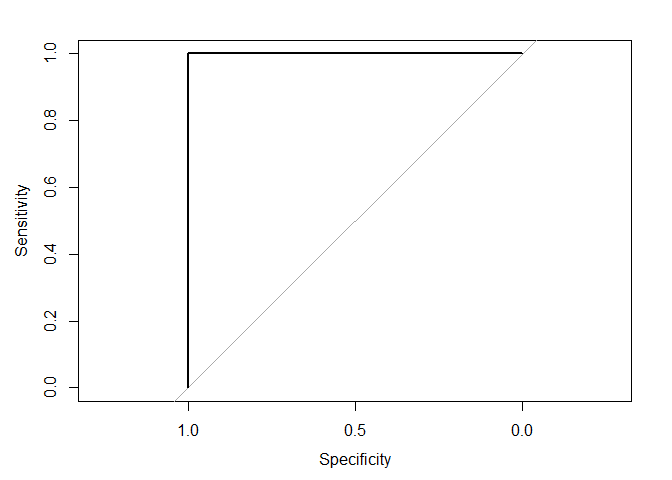

```
##
## Call:
## roc.default(response = social_media$Trouble_falling_asleep, predictor = logit_model2$fitted.values,     plot = TRUE)
##
## Data: logit_model2$fitted.values in 14 controls (social_media$Trouble_falling_asleep 0) < 7 cases (social_media$Trouble_falling_asleep 1).
## Area under the curve: 1
```

```r
predict_dataF <- as.factor(ifelse(test=as.numeric(predict_data>0.5) == 0, yes="0", no="1"))
roc(social_media$Trouble_falling_asleep,logit_model2$fitted.values,plot=TRUE)
```

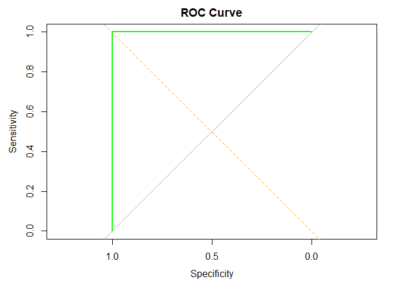

```r
predicted_prob <- predict(logit_model2, type = "response")

# Create prediction object
predictions <- prediction(predicted_prob, predict_dataF)

roc_curve <- roc(social_media$Trouble_falling_asleep, predicted_prob)
# Plot ROC curve
plot(roc_curve, main = "ROC Curve", col = "green", lwd = 2)
abline(a = 0, b = 1, lty = 2, col = "orange")
```

```r
auc_value <- auc(roc_curve)
cat("AUC:", auc_value, "\n")
```

```
## AUC: 1
```

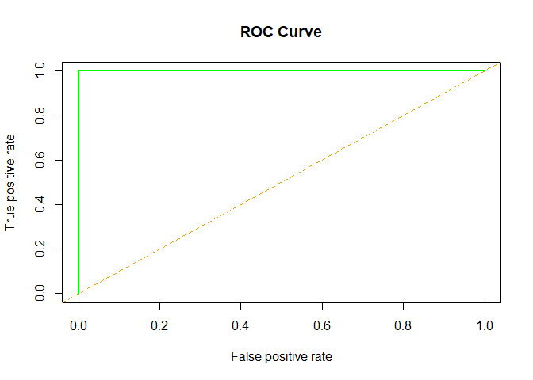

```r
# Calculate performance measures
perf <- performance(predictions, "tpr", "fpr")

# Plot ROC curve
plot(perf, main = "ROC Curve", col = "green", lwd = 2)
abline(a = 0, b = 1, lty = 2, col = "orange")
```

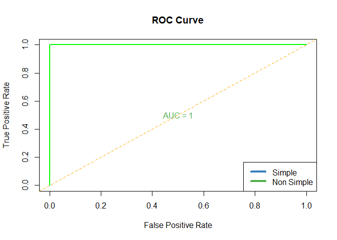

```r
# Plot ROC curve
plot(perf, main = "ROC Curve", col = "green", lwd = 2,
     xlab = "False Positive Rate", ylab = "True Positive Rate",
     xlim = c(0, 1), ylim = c(0, 1))
abline(a = 0, b = 1, lty = 2, col = "orange")  # Diagonal line for reference

# Add AUC value to the plot
auc_value <- performance(predictions, "auc")@y.values[[1]]
text(0.5, 0.5, paste("AUC =", round(auc_value, 2)), col = "#4daf4a", lwd=4)

plot.roc(social_media$Trouble_falling_asleep , logit_model2$fitted.values, percent=TRUE, col="#4daf4a", lwd=4, print.auc=TRUE, add=TRUE, print.auc.y=40)
legend("bottomright", legend=c("Simple", "Non Simple"), col=c("#377eb8", "#4daf4a"), lwd=4)
```

The logistic regression model uses a number of variables, such as user characteristics and social media usage, to assess the probability of having sleep problems. However, some coefficients are not specified because of data singularities. The model’s tiny coefficients near 0 show that traits like “character19!@s” and “characterpeace” have little bearing on the risk of having sleep problems.

#### Model Accuracy

```r
predicted <- predict(logit_model, type = "response")
predicted_binary <- ifelse(predicted > 0.5, 1, 0)
confusion <- table(predicted_binary, social_media$Trouble_falling_asleep)
accuracy <- sum(diag(confusion)) / sum(confusion)
print(accuracy)
```

```
## [1] 0.8095238
```

### Discriminant Analysis

```r
mydata <- read_excel("social_media_cleaned.xlsx")
mydata$Binary_tfs <- ifelse(mydata$Trouble_falling_asleep == "1", 1, 0)
```

#### Model Development

```r
lda_model <- lda(Binary_tfs ~ Instagram +   LinkedIn + SnapChat + Twitter + `Whatsapp/Wechat` + youtube +   OTT +   Reddit, data = mydata)
```

#### Model Acceptance

```r
summary(lda_model)
```

```
##         Length Class  Mode
## prior    2     -none- numeric
## counts   2     -none- numeric
## means   16     -none- numeric
## scaling  8     -none- numeric
## lev      2     -none- character
## svd      1     -none- numeric
## N        1     -none- numeric
## call     3     -none- call
## terms    3     terms  call
## xlevels  0     -none- list
```

```r
print(lda_model)
```

```
## Call:
## lda(Binary_tfs ~ Instagram + LinkedIn + SnapChat + Twitter +
##     `Whatsapp/Wechat` + youtube + OTT + Reddit, data = mydata)
##
## Prior probabilities of groups:
##         0         1
## 0.6666667 0.3333333
##
## Group means:
##   Instagram LinkedIn  SnapChat   Twitter `Whatsapp/Wechat`  youtube      OTT
## 0  4.696429 3.836905 0.8392857 0.6500000          6.604762 2.926190 2.361905
## 1  8.376190 3.198095 4.2428571 0.4404762          6.079048 3.065238 2.358571
##      Reddit
## 0 0.6785714
## 1 0.2157143
##
## Coefficients of linear discriminants:
##                           LD1
## Instagram          0.28281168
## LinkedIn          -0.11485929
## SnapChat           0.23104580
## Twitter            0.15401514
## `Whatsapp/Wechat` -0.11793471
## youtube            0.16244843
## OTT               -0.10662432
## Reddit            -0.09602332
```

#### Residual Analysis

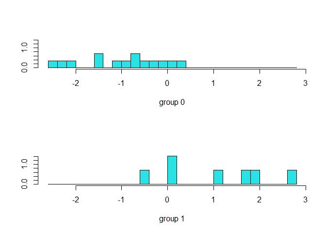

```r
plot(lda_model)
```

#### Prediction

```r
lda_predictions <- predict(lda_model, newdata = mydata)
lda_predictions
```

```
## $class
##  [1] 0 1 0 0 1 0 0 0 0 0 0 0 1 0 0 0 0 0 0 1 0
## Levels: 0 1
##
## $posterior
##              0           1
## 1  0.976834863 0.023165137
## 2  0.188390685 0.811609315
## 3  0.994420116 0.005579884
## 4  0.917812437 0.082187563
## 5  0.054533293 0.945466707
## 6  0.993792292 0.006207708
## 7  0.894233002 0.105766998
## 8  0.849823061 0.150176939
## 9  0.559002014 0.440997986
```

[output cut: 36 more lines]

```r
predicted_classes <- lda_predictions$class
predicted_classes
```

```
##  [1] 0 1 0 0 1 0 0 0 0 0 0 0 1 0 0 0 0 0 0 1 0
## Levels: 0 1
```

```r
lda_predictions$x
```

```
##            LD1
## 1  -1.19320328
## 2   1.41106900
## 3  -1.91474761
## 4  -0.52804920
## 5   2.10810509
## 6  -1.86105421
## 7  -0.38874810
## 8  -0.18774519
## 9   0.56122200
## 10 -0.81025811
## 11  0.33736914
## 12 -0.24409778
## 13  3.09067868
## 14  0.40710233
## 15 -1.14923415
## 16  0.34278302
## 17  0.31400553
## 18 -0.04524018
## 19 -0.28904512
## 20  2.21965151
## 21 -2.18056336
```

```r
predicted_probabilities <- as.data.frame(lda_predictions$posterior)
predicted_probabilities
```

```
##              0           1
## 1  0.976834863 0.023165137
## 2  0.188390685 0.811609315
## 3  0.994420116 0.005579884
## 4  0.917812437 0.082187563
## 5  0.054533293 0.945466707
## 6  0.993792292 0.006207708
## 7  0.894233002 0.105766998
## 8  0.849823061 0.150176939
## 9  0.559002014 0.440997986
## 10 0.951511087 0.048488913
## 11 0.664691181 0.335308819
## 12 0.863631008 0.136368992
## 13 0.008037163 0.991962837
## 14 0.632968941 0.367031059
## 15 0.974761902 0.025238098
## 16 0.662276600 0.337723400
## 17 0.675011651 0.324988349
## 18 0.809775601 0.190224399
## 19 0.873864201 0.126135799
## 20 0.044121353 0.955878647
## 21 0.996711313 0.003288687
```

```r
pred <- prediction(predicted_probabilities[,2], mydata$Binary_tfs)
```

#### Model Accuracy

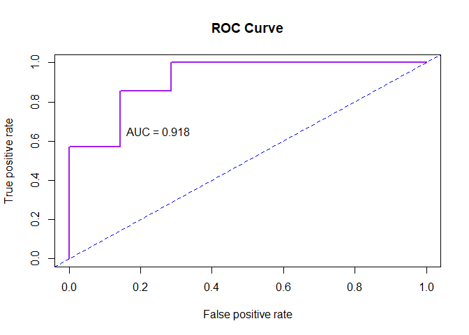

```r
roc.perf = performance(pred, measure = "tpr", x.measure = "fpr")
auc.train <- performance(pred, measure = "auc")
auc.train <- auc.train@y.values
plot(roc.perf, main = "ROC Curve", col = "purple", lwd = 2)
abline(a = 0, b = 1, lty = 2, col = "blue")
text(x = .25, y = .65 ,paste("AUC = ", round(auc.train[[1]],3), sep = ""))
```